# Homework Assignment 1

Garrett Schaub

Assigned: Oct 24, 2020, Due Sun Nov 01, 2020 11:59PM

# Introduction

## Reading Data Files

```
## [1] 336776     20
```

## HW-1 Instructions

> Our class emphasizes clear communication of data analysis results to non-technical audiences. I expect your HTML output documents to be readable and well formatted. I expect you to put ample comments in your R code to make the code understandable. Along with accuracy of results, I am looking for quality of presentation as well. This homework is due by **11:59PM on Nov 01st**. To complete this assignment, follow these steps:
1. Create a new RStudio Project for this HW. Sync the project directory with a GitHub Repository (see instructions on Canvas on how to do that).
2. Download the `HW1.Rmd` file from Canvas. Save the file in the RStudio Project Directory.
3. Open `HW1.Rmd` in RStudio. Replace the “Your Name Here” text in the `author:` field with your name.
4. Supply your solutions to the homework by editing `HW1.Rmd`.
5. Run your code in the Console and Knit HTML frequently to check for errors.
6. You may find it easier to solve a problem by interacting only with the Console at first.
7. When you have completed the homework please check that your knits correctly when you click `Knit HTML`.
8. “Push” all your local changes to the GitHub Repo for the project.
9. Submit your RMD file, the HTML output and a link to your GitHub Repo on Canvas.

## Data frame basics

We will continue working with the nycflights dataset we looked at in class. **Please be sure to keep the data file in the same directory as the RMD file - your project directory.**

First - make sure that you are reading the data correctly and doing all the data cleaning steps that we did in class. Feel free to go beyond our class work in cleaning the data if you feel the need.

I now would like you to answer the following - all in their own separate R code blocks.

### Data Exploration

```
## [1] 16
```

```
## [1] 32
```

```
## [1] 20
```

```
## [1] 112
```

The dataset for NYC flights is quite diverse.  
There are : 16 different airlines (carriers).  
There are : 32 flights by airline code oo.  
With the shortest flight being : 20 minutes  
The data is quite granular, for instance on Jan 12th, 2013 for United Airlines there were: 112 flights.

Let’s first do some simple exploration of this data.

- How many airlines are there? (Hint: `levels` and `length` can be useful here)
- How many flights there were by the airline with code `OO`? (Hint: `nrow` can be useful here along with logical indexing)
- How long is the shortest flight out of any NYC airport? (Hint: `min` can be useful, remember to handle `NA` values)
- How many flights where there by United Airlines (code: UA) on Jan 12th 2013?

### Arrival Delay

```
## [1] 6.129972
```

```
## [1] -3
```

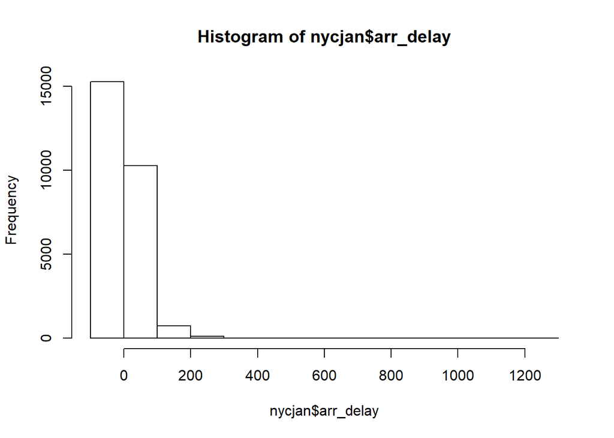

Lets focus on Arrival Delay.

- What was the average arrival delay for all airports and all airlines combined in Jan 2013?
- Whats was the median arrival delay for all airports and all airlines combined in Jan 2013?

The average and median arrival delay for all airport and airlines in Jan 2013 was

mean: 6.129972

median: -3

Based on your answers to the two questions above, what can you say about the distribution of arrival delays? Provide your answer in a text paragraph form.

Based on the above values the mean is skewed to the right. In this case the median value or central datapoint is negative for flights, (which means planes arrive ahead of schedule on average for 2013). The mean is ~6 minutes, which means that as expected some flights are delayed by a large amount and therefore skew the data. In this case a long tail means that it is hard to predict exact timeframes since the variance could be very high in specific scenarios. For the most part planes will be slightly early.